# Bicycle Sharing

Vince Trost

October 14, 2016

*Source file* ⇒ BicycleSharing.Rmd

### Preliminary Tasks

```r
#read in the Stations Data about locations of each of the stations
Stations <- mosaic::read.file("http://tiny.cc/dcf/DC-Stations.csv")
```

```
## Reading data with read.csv()
```

```r
#read in the Trips data about the rental history over Q4 of 2014
data_site <- "http://tiny.cc/dcf/2014-Q4-Trips-History-Data.rds"
Trips <- readRDS(gzcon(url(data_site)))
```

We are only working with a few variables from each dataset:  
From **Stations**:

- `lat` and `long`: the latitude and longitude of the station, respectively
- `name`: the name of the station

From **Trips**:

- `sstation`: name of the station where the bike was checked out
- `estation`: name of the station where the bike was returned
- `client`: indicates whether the customer is a “regular” user who has paid the yearly membership fee or a “casual” user who has paid a fee for a 5-day membership
- `sdate`: date and time of checkout
- `edate`: date and time of return

**Given**: distribution of times that bikes were checked out-

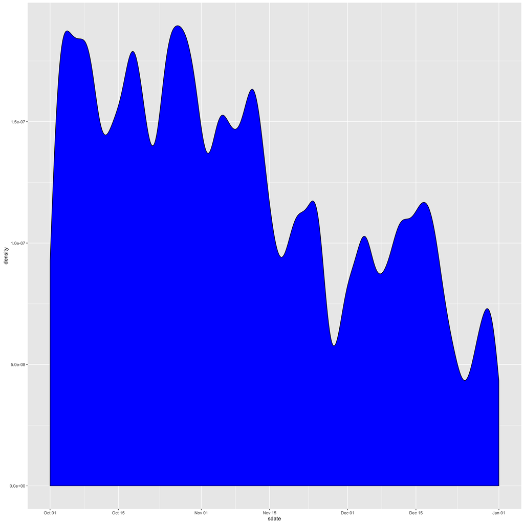

```r
Trips %>%
  ggplot(aes(x=sdate)) +
  geom_density(fill="blue")
```

### Problem A.1- How long?

**Your Turn**: Make a box and whisker plot showing the distribution of the duration of rental events, broken down by the `client` type. The duration of the rental can be calculated as `as.numeric(edate - sdate)`.

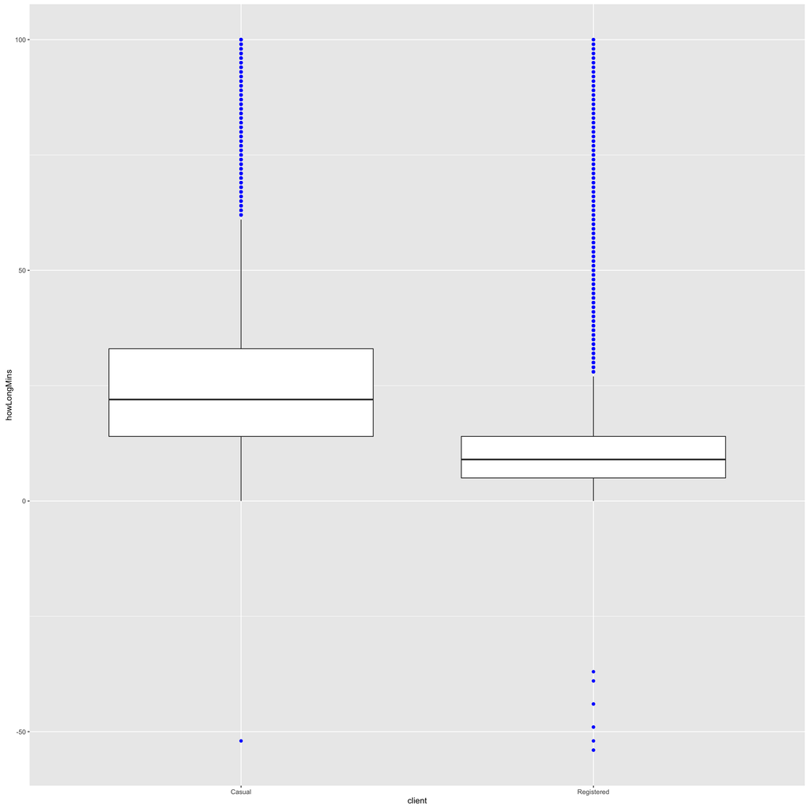

```r
Trips <- Trips %>%
  mutate(howLongMins = as.numeric(edate-sdate)/60)  #divide by 60 to get minutes- initial form is seconds
Trips <- Trips %>%
  filter(howLongMins <= 100)  #100 minutes was a reasonalbe point to cut it off at
Trips %>%
  ggplot(aes(x=client, y=howLongMins)) +
  geom_boxplot(mapping=NULL, data=NULL, stat="boxplot", position="dodge", outlier.color="blue")
```

### Problem A.2- When are bikes used?

We will use a package called `lubridate` to get the discrete components of a date.

- The day of the year (1-365): `lubridate::yday(sdate)`
- The day of the week (Sunday to Saturday): `lubridate::wday(sdate)`
- The hour of day: `lubridate::hour(sdate)`
- The minute of the hour: `lubridate::minute(sdate)`

**Your Turn**: Make histograms or density plots of each of the above discrete components.

##### The Day of the Year:

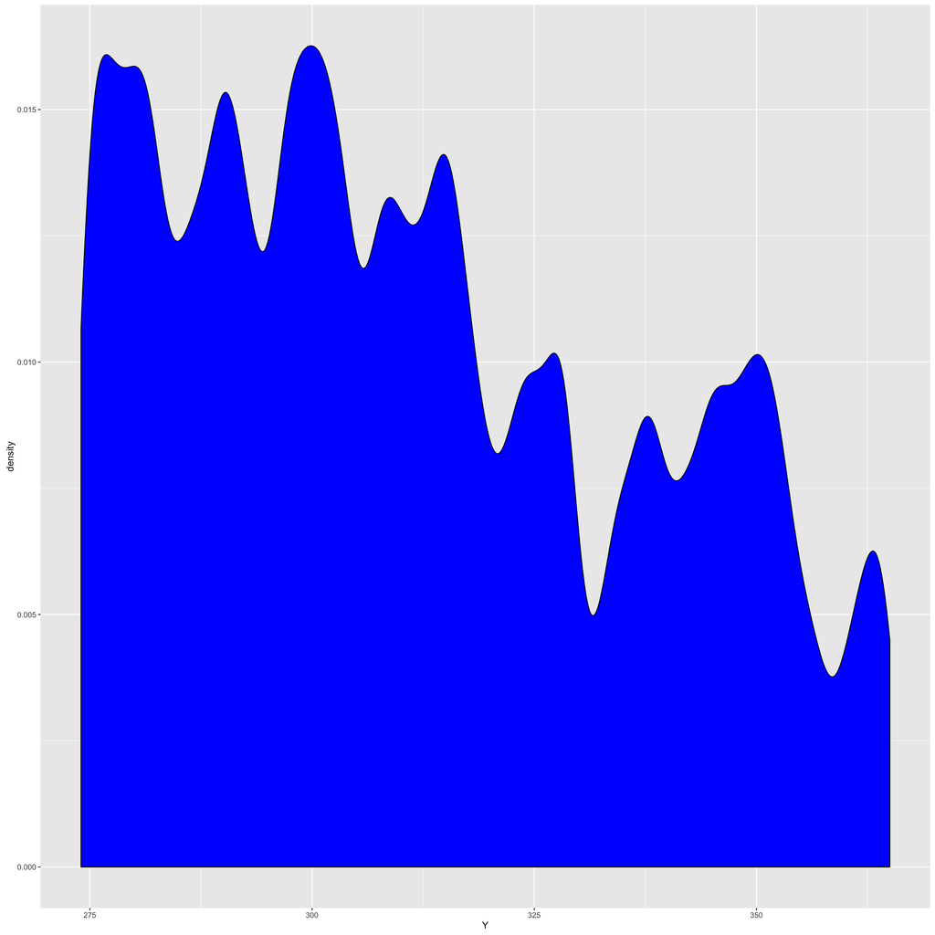

```r
Trips %>%
  mutate(Y = lubridate::yday(sdate)) %>%
  ggplot(aes(x=Y)) +
  geom_density(fill="blue")
```

This shows us that bike rentals decrease as the winter goes on.

##### The Day of the Week:

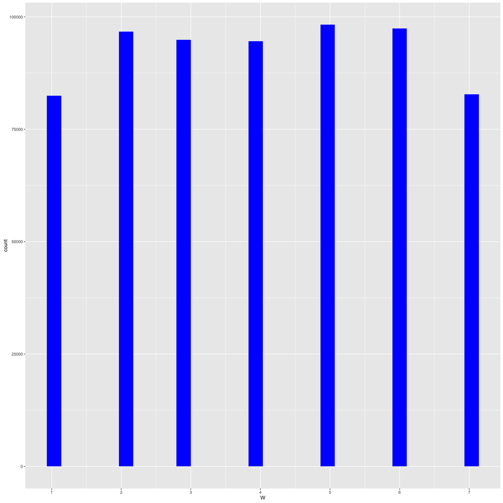

```r
Trips %>%
  mutate(W = lubridate::wday(sdate)) %>%
  ggplot(aes(x=W)) +
  geom_histogram(fill="blue") +
  scale_x_continuous(breaks = c(1:7))
```

This shows us that a majority of people rent bikes during the week to go to work presumably…

##### The Hour of Day:

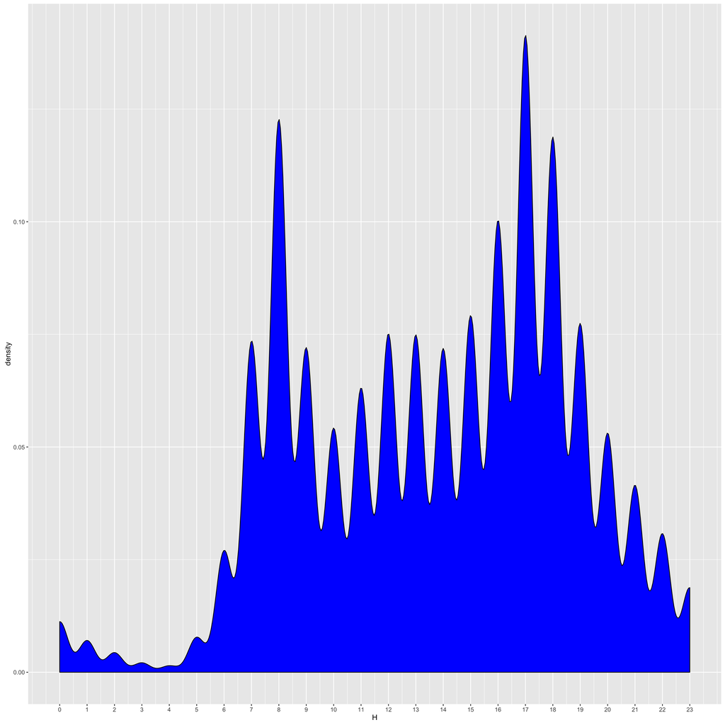

```r
Trips %>%
  mutate(H = lubridate::hour(sdate)) %>%
  ggplot(aes(x=H)) +
  geom_density(fill="blue") +
  scale_x_continuous(breaks= c(0:23))
```

This shows us that the peak hours of the day for rentals are around rush hour start and end.

##### The Minute of the Hour:

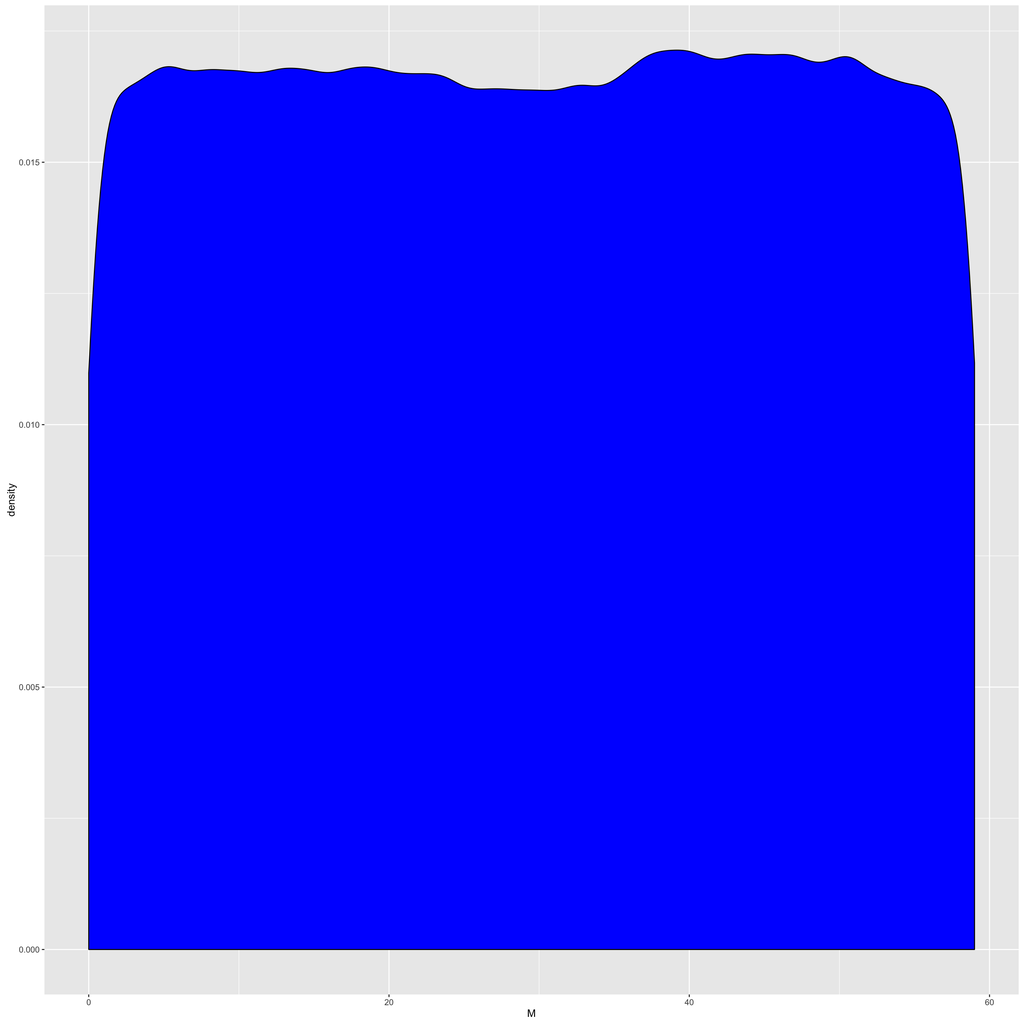

```r
Trips %>%
  mutate(M = lubridate::minute(sdate)) %>%
  ggplot(aes(x=M)) +
  geom_density(fill="blue")
```

This shows us that the amount of rentals is pretty evenly distributed over the hour.

### Problem A.3- How far?

Find the distance between each pair of staions. You know the position from the `lat` and `long` variables in `Stations`. This is enough informatino to find the distance. The calculation has been implemented in the `haversine()` function.

```r
source("http://tiny.cc/dcf/haversine.R")
```

`haversine()` is a transformation function. To use it, create a data table where a case is a *pair* of stations and there are variabels for the latitude and longitude of the starting station and the ending station. To do this, join the `Station` data to itself. The following statements show how to create appropriately named variables for joining.

```r
Simple <- Stations %>%
  select(name, lat, long) %>%
  rename(sstation=name)
Simple2 <- Simple %>%
  rename(estation=sstation, lat2=lat, long2=long)
#looking at the head of both tables...
head(Simple, 5)
```

```
##                                     sstation      lat      long
## 1                             20th & Bell St 38.85610 -77.05120
## 2                            18th & Eads St. 38.85725 -77.05332
## 3                          20th & Crystal Dr 38.85640 -77.04920
## 4                          15th & Crystal Dr 38.86017 -77.04959
## 5 Aurora Hills Community Ctr/18th & Hayes St 38.85787 -77.05949
```

```r
head(Simple2, 5)
```

```
##                                     estation     lat2     long2
## 1                             20th & Bell St 38.85610 -77.05120
## 2                            18th & Eads St. 38.85725 -77.05332
## 3                          20th & Crystal Dr 38.85640 -77.04920
## 4                          15th & Crystal Dr 38.86017 -77.04959
## 5 Aurora Hills Community Ctr/18th & Hayes St 38.85787 -77.05949
```

The joining of `Simple` and `Simple2` should match every station to every other station. This sort of matching does not make use of any matching variables; everything is matched to everything else. This is called a *full outer join*.  
First, try the full outer join on just a few cases from each table- for example: 4 from the left and 3 from the right.

```r
merge(head(Simple, 4), head(Simple2, 3), by=NULL)
```

```
##             sstation      lat      long          estation     lat2
## 1     20th & Bell St 38.85610 -77.05120    20th & Bell St 38.85610
## 2    18th & Eads St. 38.85725 -77.05332    20th & Bell St 38.85610
## 3  20th & Crystal Dr 38.85640 -77.04920    20th & Bell St 38.85610
## 4  15th & Crystal Dr 38.86017 -77.04959    20th & Bell St 38.85610
## 5     20th & Bell St 38.85610 -77.05120   18th & Eads St. 38.85725
## 6    18th & Eads St. 38.85725 -77.05332   18th & Eads St. 38.85725
## 7  20th & Crystal Dr 38.85640 -77.04920   18th & Eads St. 38.85725
## 8  15th & Crystal Dr 38.86017 -77.04959   18th & Eads St. 38.85725
## 9     20th & Bell St 38.85610 -77.05120 20th & Crystal Dr 38.85640
## 10   18th & Eads St. 38.85725 -77.05332 20th & Crystal Dr 38.85640
## 11 20th & Crystal Dr 38.85640 -77.04920 20th & Crystal Dr 38.85640
## 12 15th & Crystal Dr 38.86017 -77.04959 20th & Crystal Dr 38.85640
##        long2
## 1  -77.05120
## 2  -77.05120
## 3  -77.05120
## 4  -77.05120
## 5  -77.05332
## 6  -77.05332
## 7  -77.05332
## 8  -77.05332
## 9  -77.04920
## 10 -77.04920
## 11 -77.04920
## 12 -77.04920
```

Now let’s do the real thing. They pose a hypothetical situation to prove our knowledge of the actions of a full outer join. Their case is that if there are 347 cases in the `Stations` data table, how many will there be in a full outer join of the two tables. The answer is 120409. With every station being matched to every other station, that would create $347^{2}$ cases.

```r
StationPairs <- merge(Simple, Simple2, by=NULL)
```

Checking the result for sensibility- make a histogram of the station-to-station distances and explain where it looks like what you would expect. (Hint: from one end of D.C. to the other is about 14.1 miles.)

```r
PairDistances <- StationPairs %>%
  mutate(distance = haversine(lat, long, lat2, long2)) %>%
  select(sstation, estation, distance)
```

Once you have `PairDistances`, you can join it with `Trips` to calculate the start-to-end distance of each trip. Use an `inner_join`.

```r
RideDists <- Trips %>%
  inner_join(PairDistances)
head(RideDists, 5)
```

```
##     duration               sdate                        sstation
## 1 0h 10m 35s 2014-10-01 00:00:00         Wisconsin Ave & O St NW
## 2  0h 4m 50s 2014-10-01 00:01:00 Columbus Circle / Union Station
## 3  1h 7m 46s 2014-10-01 00:02:00         Park Rd & Holmead Pl NW
## 4  0h 3m 45s 2014-10-01 00:01:00        20th St & Florida Ave NW
## 5  0h 20m 2s 2014-10-01 00:03:00   Metro Center / 12th & G St NW
##                 edate                 estation bikeno     client
## 1 2014-10-01 00:10:00    17th & Corcoran St NW W20503 Registered
## 2 2014-10-01 00:06:00 4th & East Capitol St NE W20487 Registered
## 3 2014-10-01 01:10:00     Utah St & 11th St N  W00080     Casual
## 4 2014-10-01 00:05:00    17th & Corcoran St NW W01229 Registered
## 5 2014-10-01 00:23:00          23rd & E St NW  W00736 Registered
##   howLongMins  distance
## 1          10 2.1903366
## 2           5 0.8740129
## 3          68 8.8491138
## 4           4 0.6286688
## 5          20 1.9215101
```

**Your Turn**: Display the distribution of the ride distances of the rides. Compare it to the distances between pairs of stations. Are they similar?

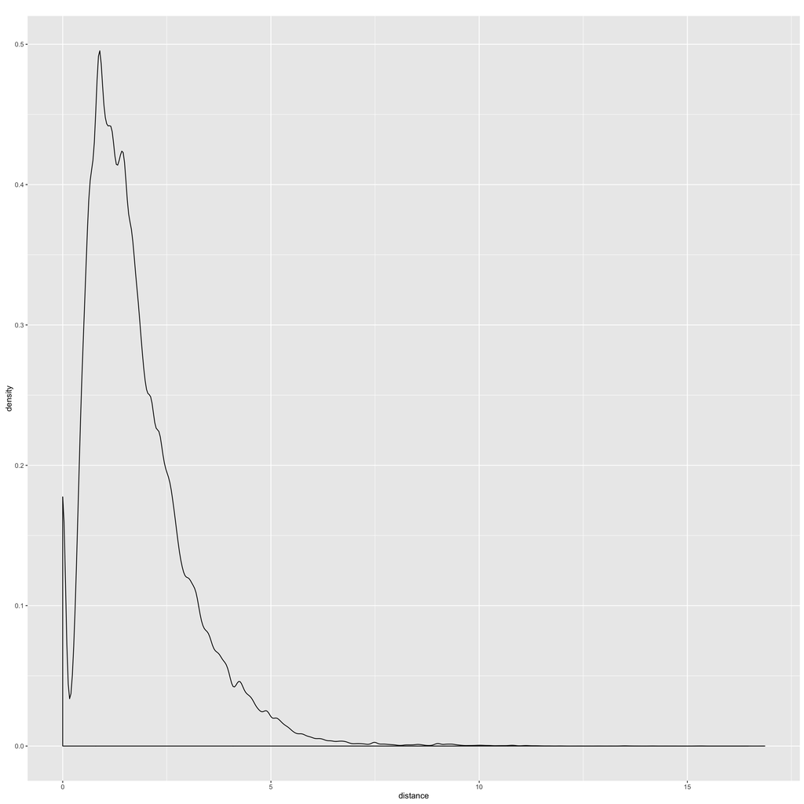

```r
#Ride Distances
ggplot( data = RideDists, aes(x = distance)) + geom_density(adjust=1) + labs(title="") + theme(legend.position="right")
```

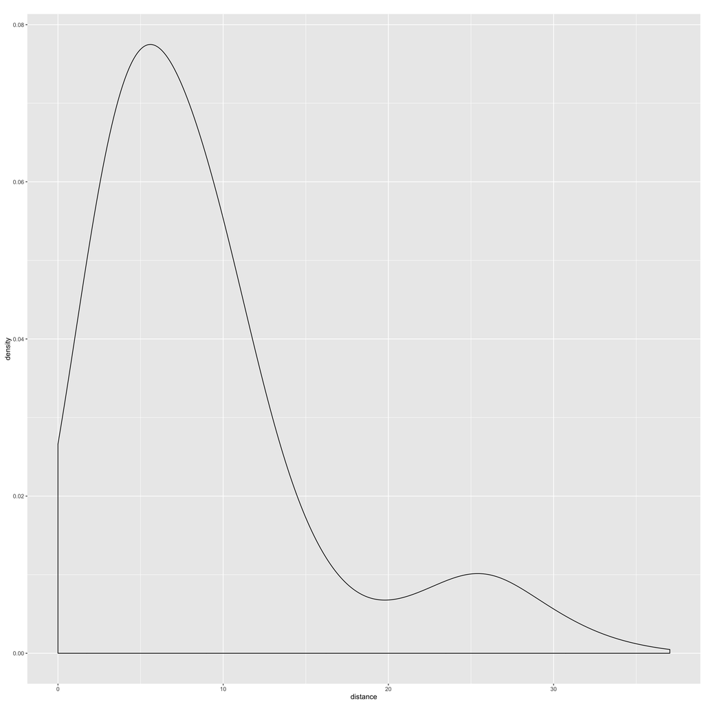

```r
#Pair Distances
ggplot( data = PairDistances, aes(x = distance)) + geom_density(adjust=5) + labs(title="") + theme(legend.position="right")
```

### Problem A.4- Mapping the Stations

Install `leaflet` to draw detailed maps.

```r
devtools::install_github("rstudio/leaflet")
```

`leaflet` works much like `ggplot()` but provides special facilities for maps. Simple map:

```r
library(leaflet)
```

```r
stationMap <-
  leaflet(Stations) %>%
  addTiles() %>%         #add the map
  addCircleMarkers(radius=2, color="red") %>%
  setView(-77.04, 38.9, zoom=12)
```

```
## Assuming 'long' and 'lat' are longitude and latitude, respectively
```

```r
stationMap
```

[interactive chart not shown]